```python
# Import pandas, numpy, matplotlib, seaborn libraries
import pandas as pd
import numpy as np
import matplotlib.pyplot as plt
import matplotlib.patches as mpatches
from matplotlib.backends.backend_pdf import PdfPages

# hide ipykernel warnings
import warnings
warnings.filterwarnings('ignore')
%matplotlib inline
```

```python
# read in data from csv file to pandas dataframe.
df = pd.read_csv('covid19-cdc-22200055.csv', keep_default_na=True,  delimiter=',', skipinitialspace=True, encoding='Windows-1252')
```

# 1. Prepare a data quality report for the CSV file.

## Check shape of CSV file

```python
df.shape
```

```
(20000, 19)
```

The dataset has 20000 entries with 19 features per entry.

## Print first and last 5 rows of CSV file

```python
df.head(5)
```

|  | case_month | res_state | state_fips_code | res_county | county_fips_code | age_group | sex | race | ethnicity | case_positive_specimen_interval | case_onset_interval | process | exposure_yn | current_status | symptom_status | hosp_yn | icu_yn | death_yn | underlying_conditions_yn |
| --- | --- | --- | --- | --- | --- | --- | --- | --- | --- | --- | --- | --- | --- | --- | --- | --- | --- | --- | --- |
| 0 | 2020-11 | CA | 6.0 | LOS ANGELES | 6037.0 | 65+ years | Female | White | Non-Hispanic/Latino | NaN | NaN | Missing | Missing | Laboratory-confirmed case | Unknown | Yes | Unknown | Yes | NaN |
| 1 | 2020-12 | MA | 25.0 | BRISTOL | 25005.0 | 65+ years | Female | White | Non-Hispanic/Latino | 0.0 | NaN | Missing | Missing | Laboratory-confirmed case | Missing | Unknown | Missing | Yes | NaN |
| 2 | 2020-12 | NY | 36.0 | RICHMOND | 36085.0 | 65+ years | Female | White | Non-Hispanic/Latino | NaN | NaN | Missing | Missing | Probable Case | Unknown | Missing | Missing | Yes | NaN |
| 3 | 2021-11 | MI | 26.0 | LIVINGSTON | 26093.0 | 65+ years | Female | White | Non-Hispanic/Latino | NaN | NaN | Missing | Yes | Laboratory-confirmed case | Symptomatic | Yes | No | Yes | Yes |
| 4 | 2020-08 | PA | 42.0 | ALLEGHENY | 42003.0 | 65+ years | Female | White | Non-Hispanic/Latino | 2.0 | 0.0 | Missing | Yes | Laboratory-confirmed case | Symptomatic | No | No | Yes | Yes |

```python
df.tail(5)
```

|  | case_month | res_state | state_fips_code | res_county | county_fips_code | age_group | sex | race | ethnicity | case_positive_specimen_interval | case_onset_interval | process | exposure_yn | current_status | symptom_status | hosp_yn | icu_yn | death_yn | underlying_conditions_yn |
| --- | --- | --- | --- | --- | --- | --- | --- | --- | --- | --- | --- | --- | --- | --- | --- | --- | --- | --- | --- |
| 19995 | 2022-02 | ID | 16.0 | ADA | 16001.0 | 18 to 49 years | Male | White | Non-Hispanic/Latino | 0.0 | NaN | Clinical evaluation | Missing | Probable Case | Unknown | No | Missing | No | NaN |
| 19996 | 2020-05 | TX | 48.0 | JOHNSON | 48251.0 | NaN | NaN | NaN | NaN | NaN | 0.0 | Missing | Missing | Laboratory-confirmed case | Symptomatic | Unknown | Missing | No | NaN |
| 19997 | 2020-07 | NC | 37.0 | MECKLENBURG | 37119.0 | 50 to 64 years | Female | Unknown | Hispanic/Latino | 0.0 | 0.0 | Missing | Unknown | Laboratory-confirmed case | Symptomatic | No | Unknown | No | NaN |
| 19998 | 2020-11 | AR | 5.0 | NaN | NaN | 65+ years | Female | White | Non-Hispanic/Latino | 0.0 | NaN | Missing | Yes | Laboratory-confirmed case | Asymptomatic | No | Unknown | No | NaN |
| 19999 | 2020-11 | FL | 12.0 | BROWARD | 12011.0 | 18 to 49 years | Female | Black | Non-Hispanic/Latino | NaN | 0.0 | Missing | Missing | Laboratory-confirmed case | Symptomatic | No | Missing | No | NaN |

## Convert features to appropriate datatypes

```python
df.dtypes
```

```
case_month                          object
res_state                           object
state_fips_code                    float64
res_county                          object
county_fips_code                   float64
age_group                           object
sex                                 object
race                                object
ethnicity                           object
case_positive_specimen_interval    float64
case_onset_interval                float64
process                             object
exposure_yn                         object
current_status                      object
symptom_status                      object
hosp_yn                             object
icu_yn                              object
death_yn                            object
underlying_conditions_yn            object
dtype: object
```

```python
# Descriptive stats for continuous features
# df.describe() by default only prints stats for the numeric columns int64 and float64.
# Often we need to change the feature data type so it more appropriately reflects whether this is
# a continuous or a categorical feature.
df.describe()
```

|  | state_fips_code | county_fips_code | case_positive_specimen_interval | case_onset_interval |
| --- | --- | --- | --- | --- |
| count | 19999.000000 | 18734.000000 | 10405.000000 | 8747.000000 |
| mean | 29.465223 | 29468.439148 | 0.156271 | -0.038527 |
| std | 13.426217 | 13227.664639 | 2.043263 | 1.577846 |
| min | 1.000000 | 1003.000000 | -63.000000 | -58.000000 |
| 25% | 18.000000 | 18147.000000 | 0.000000 | 0.000000 |
| 50% | 34.000000 | 34017.000000 | 0.000000 | 0.000000 |
| 75% | 37.000000 | 37183.000000 | 0.000000 | 0.000000 |
| max | 78.000000 | 56039.000000 | 56.000000 | 64.000000 |

```python
# Turn the following features into type 'Int64' and save them to 'continuous_features' for future reference
df['case_positive_specimen_interval'] = df['case_positive_specimen_interval'].astype('Int64')
df['case_onset_interval'] = df['case_onset_interval'].astype('Int64')
continuous_features = df.select_dtypes(['int64']).columns
df
```

|  | case_month | res_state | state_fips_code | res_county | county_fips_code | age_group | sex | race | ethnicity | case_positive_specimen_interval | case_onset_interval | process | exposure_yn | current_status | symptom_status | hosp_yn | icu_yn | death_yn | underlying_conditions_yn |
| --- | --- | --- | --- | --- | --- | --- | --- | --- | --- | --- | --- | --- | --- | --- | --- | --- | --- | --- | --- |
| 0 | 2020-11 | CA | 6.0 | LOS ANGELES | 6037.0 | 65+ years | Female | White | Non-Hispanic/Latino | <NA> | <NA> | Missing | Missing | Laboratory-confirmed case | Unknown | Yes | Unknown | Yes | NaN |
| 1 | 2020-12 | MA | 25.0 | BRISTOL | 25005.0 | 65+ years | Female | White | Non-Hispanic/Latino | 0 | <NA> | Missing | Missing | Laboratory-confirmed case | Missing | Unknown | Missing | Yes | NaN |
| 2 | 2020-12 | NY | 36.0 | RICHMOND | 36085.0 | 65+ years | Female | White | Non-Hispanic/Latino | <NA> | <NA> | Missing | Missing | Probable Case | Unknown | Missing | Missing | Yes | NaN |
| 3 | 2021-11 | MI | 26.0 | LIVINGSTON | 26093.0 | 65+ years | Female | White | Non-Hispanic/Latino | <NA> | <NA> | Missing | Yes | Laboratory-confirmed case | Symptomatic | Yes | No | Yes | Yes |
| 4 | 2020-08 | PA | 42.0 | ALLEGHENY | 42003.0 | 65+ years | Female | White | Non-Hispanic/Latino | 2 | 0 | Missing | Yes | Laboratory-confirmed case | Symptomatic | No | No | Yes | Yes |
| ... | ... | ... | ... | ... | ... | ... | ... | ... | ... | ... | ... | ... | ... | ... | ... | ... | ... | ... | ... |
| 19995 | 2022-02 | ID | 16.0 | ADA | 16001.0 | 18 to 49 years | Male | White | Non-Hispanic/Latino | 0 | <NA> | Clinical evaluation | Missing | Probable Case | Unknown | No | Missing | No | NaN |
| 19996 | 2020-05 | TX | 48.0 | JOHNSON | 48251.0 | NaN | NaN | NaN | NaN | <NA> | 0 | Missing | Missing | Laboratory-confirmed case | Symptomatic | Unknown | Missing | No | NaN |
| 19997 | 2020-07 | NC | 37.0 | MECKLENBURG | 37119.0 | 50 to 64 years | Female | Unknown | Hispanic/Latino | 0 | 0 | Missing | Unknown | Laboratory-confirmed case | Symptomatic | No | Unknown | No | NaN |
| 19998 | 2020-11 | AR | 5.0 | NaN | NaN | 65+ years | Female | White | Non-Hispanic/Latino | 0 | <NA> | Missing | Yes | Laboratory-confirmed case | Asymptomatic | No | Unknown | No | NaN |
| 19999 | 2020-11 | FL | 12.0 | BROWARD | 12011.0 | 18 to 49 years | Female | Black | Non-Hispanic/Latino | <NA> | 0 | Missing | Missing | Laboratory-confirmed case | Symptomatic | No | Missing | No | NaN |

20000 rows × 19 columns

Based on examining the data in a spreadsheet program, 2 of the features are continuous and the rest categorical.

```python
# Select columns containing categorical data
categorical_columns = df[['case_month','res_state','state_fips_code','res_county','county_fips_code','age_group','sex','race','ethnicity','process','exposure_yn','current_status','symptom_status','hosp_yn','icu_yn','death_yn','underlying_conditions_yn']].columns
# the features above were chosen as categories because
# can take on a limited and unordered set of values or categories

# Convert data type to category for these columns
for column in categorical_columns:
    df[column] = df[column].astype('category')

category_columns = df.select_dtypes(['category']).columns
all_columns = df.columns

# check data type after conversion
df.dtypes
```

```
case_month                         category
res_state                          category
state_fips_code                    category
res_county                         category
county_fips_code                   category
age_group                          category
sex                                category
race                               category
ethnicity                          category
case_positive_specimen_interval       Int64
case_onset_interval                   Int64
process                            category
exposure_yn                        category
current_status                     category
symptom_status                     category
hosp_yn                            category
icu_yn                             category
death_yn                           category
underlying_conditions_yn           category
dtype: object
```

### Data type Conversion

- Converted *'case_month'*,*'res_state'*,*'state_fips_code'*,*'res_county'*,*'county_fips_code'*,*'age_group'*,*'sex'*,*'race'*,*'ethnicity'*,*'process'*,*'exposure_yn'*,*'current_status'*,*'symptom_status'*,*'hosp_yn'*,*'icu_yn'*,*'death_yn'*,*'underlying_conditions_yn'*]].columns to categorical type.
- Converted *'case_positive_specimen_interval'*,*'case_onset_interval'* to continuous type.

## Check for duplicate row/columns

```python
#Print the number of duplicates, without the original rows that were duplicated
print('Number of duplicate (excluding first) rows in the table is: ', df.duplicated().sum())

# Check for duplicate rows.
# Use "keep=False" to mark all duplicates as true, including the original rows that were duplicated.
print('Number of duplicate rows (including first) in the table is:', df[df.duplicated(keep=False)].shape[0])
```

```
Number of duplicate (excluding first) rows in the table is:  1108
Number of duplicate rows (including first) in the table is: 1958
```

```python
# Check for duplicate columns
#First transpose the df so columns become rows, then apply the same check as above
dfT = df.T
print("Number of duplicate (excluding first) columns in the table is: ", dfT.duplicated().sum())
print("Number of duplicate (including first) columns in the table is: ",  dfT[dfT.duplicated(keep=False)].shape[0])
```

```
Number of duplicate (excluding first) columns in the table is:  0
Number of duplicate (including first) columns in the table is:  0
```

### Duplicate rows can be seen below

```python
# Show duplicate row data that can be dropped
df[df.duplicated()]
```

|  | case_month | res_state | state_fips_code | res_county | county_fips_code | age_group | sex | race | ethnicity | case_positive_specimen_interval | case_onset_interval | process | exposure_yn | current_status | symptom_status | hosp_yn | icu_yn | death_yn | underlying_conditions_yn |
| --- | --- | --- | --- | --- | --- | --- | --- | --- | --- | --- | --- | --- | --- | --- | --- | --- | --- | --- | --- |
| 82 | 2020-11 | IL | 17.0 | COOK | 17031.0 | 65+ years | Male | White | Non-Hispanic/Latino | <NA> | 0 | Missing | Missing | Laboratory-confirmed case | Missing | Missing | Missing | Yes | NaN |
| 212 | 2020-04 | MA | 25.0 | MIDDLESEX | 25017.0 | 65+ years | Male | White | Non-Hispanic/Latino | 0 | <NA> | Missing | Missing | Laboratory-confirmed case | Missing | Yes | Missing | Yes | NaN |
| 220 | 2020-12 | CA | 6.0 | LOS ANGELES | 6037.0 | 65+ years | Female | Asian | Non-Hispanic/Latino | <NA> | <NA> | Missing | Missing | Laboratory-confirmed case | Unknown | No | Missing | Yes | NaN |
| 375 | 2020-05 | IL | 17.0 | COOK | 17031.0 | 50 to 64 years | Male | White | Hispanic/Latino | <NA> | 0 | Missing | Missing | Laboratory-confirmed case | Missing | Yes | Missing | Yes | NaN |
| 455 | 2021-01 | CA | 6.0 | LOS ANGELES | 6037.0 | 65+ years | Female | White | Hispanic/Latino | <NA> | <NA> | Missing | Missing | Laboratory-confirmed case | Unknown | Yes | Yes | Yes | NaN |
| ... | ... | ... | ... | ... | ... | ... | ... | ... | ... | ... | ... | ... | ... | ... | ... | ... | ... | ... | ... |
| 19942 | 2020-12 | NC | 37.0 | WAKE | 37183.0 | 0 - 17 years | Female | White | Non-Hispanic/Latino | 0 | <NA> | Missing | Unknown | Laboratory-confirmed case | Unknown | Unknown | Unknown | No | NaN |
| 19951 | 2022-01 | NC | 37.0 | WAKE | 37183.0 | 18 to 49 years | Male | White | Non-Hispanic/Latino | 0 | <NA> | Missing | Missing | Laboratory-confirmed case | Unknown | Unknown | Unknown | No | NaN |
| 19967 | 2020-11 | SC | 45.0 | YORK | 45091.0 | 18 to 49 years | Female | Black | Non-Hispanic/Latino | <NA> | 0 | Missing | Missing | Laboratory-confirmed case | Symptomatic | No | Missing | No | NaN |
| 19969 | 2021-12 | NC | 37.0 | MECKLENBURG | 37119.0 | 18 to 49 years | Female | Unknown | Unknown | 0 | <NA> | Missing | Missing | Laboratory-confirmed case | Unknown | Unknown | Unknown | No | NaN |
| 19986 | 2021-01 | TX | 48.0 | HARRIS | 48201.0 | 18 to 49 years | Male | Unknown | Unknown | <NA> | <NA> | Missing | Missing | Laboratory-confirmed case | Missing | No | Missing | No | NaN |

1108 rows × 19 columns

#### The duplicate checks seems to be working as expected.

Duplicate rows will now be dropped from the original data frame.

```python
df = df.drop_duplicates()
print('Duplicate remaining rows:', df[df.duplicated()].shape[0])
```

```
Duplicate remaining rows: 0
```

## Check for constant columns

```python
# Print table with categorical statistics
df.select_dtypes(['category']).describe().T
```

|  | count | unique | top | freq |
| --- | --- | --- | --- | --- |
| case_month | 18892 | 35 | 2022-01 | 2349 |
| res_state | 18891 | 49 | NY | 1897 |
| state_fips_code | 18891.0 | 49.0 | 36.0 | 1897.0 |
| res_county | 17679 | 864 | MIAMI-DADE | 377 |
| county_fips_code | 17679.0 | 1208.0 | 12086.0 | 377.0 |
| age_group | 18730 | 5 | 18 to 49 years | 7294 |
| sex | 18450 | 4 | Female | 9626 |
| race | 16534 | 8 | White | 11679 |
| ethnicity | 16342 | 4 | Non-Hispanic/Latino | 11324 |
| process | 18892 | 9 | Missing | 17136 |
| exposure_yn | 18892 | 3 | Missing | 16231 |
| current_status | 18892 | 2 | Laboratory-confirmed case | 15867 |
| symptom_status | 18892 | 4 | Symptomatic | 8912 |
| hosp_yn | 18892 | 4 | No | 9536 |
| icu_yn | 18892 | 4 | Missing | 14622 |
| death_yn | 18892 | 2 | No | 14354 |
| underlying_conditions_yn | 1723 | 2 | Yes | 1701 |

**Categorical Data**

- *current_status* has 2 unique values
- *death_yn* has 2 unique values
- *underlying_conditions_yn* has 2 unique values
- This implies that a particular feature does not contain a single constant value in all of the rows. Thus in this case, none of the continuous features are constant. #### Conclusion - No constant columns for Categorical columns

```python
# Print table with continuous statistics
df.select_dtypes(include=['int64']).describe().T
```

|  | count | mean | std | min | 25% | 50% | 75% | max |
| --- | --- | --- | --- | --- | --- | --- | --- | --- |
| case_positive_specimen_interval | 10000.0 | 0.1612 | 2.083758 | -63.0 | 0.0 | 0.0 | 0.0 | 56.0 |
| case_onset_interval | 8460.0 | -0.039716 | 1.604339 | -58.0 | 0.0 | 0.0 | 0.0 | 64.0 |

**Continuous Data** - Reviewing the continuous data above we can see all have a non zero standard deviation.

- This implies that a particular feature does not contain a single constant value in all of the rows. Thus in this case, none of the continuous features are constant. #### Conclusion - No constant columns for Continuous columns

## Check for Irregular cardinalities & permitted values

```python
# Check for irregular cardinality & permitted values in categorical features.
print("The earlier month of the Clinical Date or the Date Received by CDC:", pd.unique(df["case_month"].ravel()))
print("State of residence:", pd.unique(df["res_state"].ravel()))
print("State FIPS code:", pd.unique(df["state_fips_code"].ravel()))
print("County of residence:", pd.unique(df["res_county"].ravel()))
print("County FIPS code:", pd.unique(df["county_fips_code"].ravel()))
print("Age group:", pd.unique(df["age_group"].ravel()))
print("Sex:", pd.unique(df["sex"].ravel()))
print("Race:", pd.unique(df["race"].ravel()))
print("Ethnicity", pd.unique(df["ethnicity"].ravel()))
print("Under what process was the case first identified:", pd.unique(df["process"].ravel()))
print("If the patient have any of the known exposures:", pd.unique(df["exposure_yn"].ravel()))
print("What is the current status of this person? :", pd.unique(df["current_status"].ravel()))
print("What is the symptom status of this person? :", pd.unique(df["symptom_status"].ravel()))
print("Was the patient hospitalized? :", pd.unique(df["hosp_yn"].ravel()))
print("Was the patient admitted to an intensive care unit (ICU)? :", pd.unique(df["icu_yn"].ravel()))
print("Did the patient have one or more of the underlying medical conditions and risk behaviors? :", pd.unique(df["underlying_conditions_yn"].ravel()))
print("Did the patient die as a result of this illness? :", pd.unique(df["death_yn"].ravel()))
```

```
The earlier month of the Clinical Date or the Date Received by CDC: ['2020-11', '2020-12', '2021-11', '2020-08', '2020-04', ..., '2022-10', '2022-03', '2021-06', '2022-11', '2020-02']
Length: 35
Categories (35, object): ['2020-01', '2020-02', '2020-03', '2020-04', ..., '2022-08', '2022-09', '2022-10', '2022-11']
State of residence: ['CA', 'MA', 'NY', 'MI', 'PA', ..., 'AK', 'GU', 'VT', 'VI', NaN]
Length: 50
Categories (49, object): ['AK', 'AL', 'AR', 'AZ', ..., 'VT', 'WA', 'WI', 'WY']
State FIPS code: [6.0, 25.0, 36.0, 26.0, 42.0, ..., 2.0, 66.0, 50.0, 78.0, NaN]
Length: 50
Categories (49, float64): [1.0, 2.0, 4.0, 5.0, ..., 56.0, 66.0, 72.0, 78.0]
County of residence: ['LOS ANGELES', 'BRISTOL', 'RICHMOND', 'LIVINGSTON', 'ALLEGHENY', ..., 'WINDHAM', 'EAGLE', 'CHEBOYGAN', 'CERRO GORDO', 'HARRISONBURG CITY']
Length: 865
Categories (864, object): ['ADA', 'ADAIR', 'ADAMS', 'ADDISON', ..., 'YAVAPAI', 'YELLOWSTONE', 'YORK', 'YUMA']
County FIPS code: [6037.0, 25005.0, 36085.0, 26093.0, 42003.0, ..., 13089.0, 8037.0, 26031.0, 19033.0, 51660.0]
Length: 1209
Categories (1208, float64): [1003.0, 1009.0, 1015.0, 1017.0, ..., 56025.0, 56029.0, 56037.0, 56039.0]
Age group: ['65+ years', '50 to 64 years', '18 to 49 years', NaN, 'Missing', '0 - 17 years']
Categories (5, object): ['0 - 17 years', '18 to 49 years', '50 to 64 years', '65+ years', 'Missing']
Sex: ['Female', 'Male', NaN, 'Unknown', 'Missing']
Categories (4, object): ['Female', 'Male', 'Missing', 'Unknown']
Race: ['White', 'Black', NaN, 'Missing', 'Unknown', 'Asian', 'American Indian/Alaska Native', 'Multiple/Other', 'Native Hawaiian/Other Pacific Islander']
Categories (8, object): ['American Indian/Alaska Native', 'Asian', 'Black', 'Missing', 'Multiple/Other', 'Native Hawaiian/Other Pacific Islander', 'Unknown', 'White']
Ethnicity ['Non-Hispanic/Latino', 'Hispanic/Latino', NaN, 'Unknown', 'Missing']
Categories (4, object): ['Hispanic/Latino', 'Missing', 'Non-Hispanic/Latino', 'Unknown']
Under what process was the case first identified: ['Missing', 'Unknown', 'Multiple', 'Clinical evaluation', 'Routine surveillance', 'Laboratory reported', 'Contact tracing of case patient', 'Provider reported', 'Other']
Categories (9, object): ['Clinical evaluation', 'Contact tracing of case patient', 'Laboratory reported', 'Missing', ..., 'Other', 'Provider reported', 'Routine surveillance', 'Unknown']
If the patient have any of the known exposures: ['Missing', 'Yes', 'Unknown']
Categories (3, object): ['Missing', 'Unknown', 'Yes']
What is the current status of this person? : ['Laboratory-confirmed case', 'Probable Case']
Categories (2, object): ['Laboratory-confirmed case', 'Probable Case']
What is the symptom status of this person? : ['Unknown', 'Missing', 'Symptomatic', 'Asymptomatic']
Categories (4, object): ['Asymptomatic', 'Missing', 'Symptomatic', 'Unknown']
Was the patient hospitalized? : ['Yes', 'Unknown', 'Missing', 'No']
Categories (4, object): ['Missing', 'No', 'Unknown', 'Yes']
Was the patient admitted to an intensive care unit (ICU)? : ['Unknown', 'Missing', 'No', 'Yes']
Categories (4, object): ['Missing', 'No', 'Unknown', 'Yes']
Did the patient have one or more of the underlying medical conditions and risk behaviors? : [NaN, 'Yes', 'No']
Categories (2, object): ['No', 'Yes']
Did the patient die as a result of this illness? : ['Yes', 'No']
Categories (2, object): ['No', 'Yes']
```

#### Conclusion

- As we can see from the printed values above, invalid values such as "unknown" and "missing" should be converted to null values in order to be counted by the isnull method. The invalid values conversion processes are as follows.

## Check for invalid Values, i.g. Null,Nan,Missing and Unknown

```python
#Missing data all features
df.isnull().sum()
```

```
case_month                             0
res_state                              1
state_fips_code                        1
res_county                          1213
county_fips_code                    1213
age_group                            162
sex                                  442
race                                2358
ethnicity                           2550
case_positive_specimen_interval     8892
case_onset_interval                10432
process                                0
exposure_yn                            0
current_status                         0
symptom_status                         0
hosp_yn                                0
icu_yn                                 0
death_yn                               0
underlying_conditions_yn           17169
dtype: int64
```

```python
# Values of Unknown and Missing is also invalid
# Convert values of 'Unknown' and 'Missing' to NAN value for category column in order to get the sum of null value

useless_values = ['Unknown', 'Missing']

for i in all_columns:
    df[i] = df[i].replace(useless_values, np.nan)

# Check Nan value again and we can see it contains more than before
# for example
# before: sex                                  442
# noe:    sex                                  537
df.isnull().sum()
```

```
case_month                             0
res_state                              1
state_fips_code                        1
res_county                          1213
county_fips_code                    1213
age_group                            187
sex                                  537
race                                4551
ethnicity                           5944
case_positive_specimen_interval     8892
case_onset_interval                10432
process                            17223
exposure_yn                        17029
current_status                         0
symptom_status                      9685
hosp_yn                             6259
icu_yn                             17251
death_yn                               0
underlying_conditions_yn           17169
dtype: int64
```

#### Conclusion

- The null values converted works as expected.

### Check for constant columns after converting 'Missing' and 'Unknown' value to null value

```python
# Print table with categorical statistics
df.select_dtypes(['category']).describe().T

# additionaly, the unique value of 'exposure_yn' is 1 after the coversion, which
# will be handled later
```

|  | count | unique | top | freq |
| --- | --- | --- | --- | --- |
| case_month | 18892 | 35 | 2022-01 | 2349 |
| res_state | 18891 | 49 | NY | 1897 |
| state_fips_code | 18891.0 | 49.0 | 36.0 | 1897.0 |
| res_county | 17679 | 864 | MIAMI-DADE | 377 |
| county_fips_code | 17679.0 | 1208.0 | 12086.0 | 377.0 |
| age_group | 18705 | 4 | 18 to 49 years | 7294 |
| sex | 18355 | 2 | Female | 9626 |
| race | 14341 | 6 | White | 11679 |
| ethnicity | 12948 | 2 | Non-Hispanic/Latino | 11324 |
| process | 1669 | 7 | Clinical evaluation | 807 |
| exposure_yn | 1863 | 1 | Yes | 1863 |
| current_status | 18892 | 2 | Laboratory-confirmed case | 15867 |
| symptom_status | 9207 | 2 | Symptomatic | 8912 |
| hosp_yn | 12633 | 2 | No | 9536 |
| icu_yn | 1641 | 2 | No | 1181 |
| death_yn | 18892 | 2 | No | 14354 |
| underlying_conditions_yn | 1723 | 2 | Yes | 1701 |

```python
# print values for columns with only 1 or 2 unique values
print('sex:' + str(df['sex'].values))
print('ethnicity:' + str(df['ethnicity'].values))
print('exposure_yn:' + str(df['exposure_yn'].values))
print('current_status:' + str(df['current_status'].values))
print('symptom_status:' + str(df['symptom_status'].values))
print('hosp_yn:' + str(df['hosp_yn'].values))
print('icu_yn:' + str(df['icu_yn'].values))
print('death_yn:' + str(df['death_yn'].values))
print('underlying_conditions_yn:' + str(df['underlying_conditions_yn'].values))
```

```
sex:['Female', 'Female', 'Female', 'Female', 'Female', ..., 'Male', NaN, 'Female', 'Female', 'Female']
Length: 18892
Categories (2, object): ['Female', 'Male']
ethnicity:['Non-Hispanic/Latino', 'Non-Hispanic/Latino', 'Non-Hispanic/Latino', 'Non-Hispanic/Latino', 'Non-Hispanic/Latino', ..., 'Non-Hispanic/Latino', NaN, 'Hispanic/Latino', 'Non-Hispanic/Latino', 'Non-Hispanic/Latino']
Length: 18892
Categories (2, object): ['Hispanic/Latino', 'Non-Hispanic/Latino']
exposure_yn:[NaN, NaN, NaN, 'Yes', 'Yes', ..., NaN, NaN, NaN, 'Yes', NaN]
Length: 18892
Categories (1, object): ['Yes']
current_status:['Laboratory-confirmed case', 'Laboratory-confirmed case', 'Probable Case', 'Laboratory-confirmed case', 'Laboratory-confirmed case', ..., 'Probable Case', 'Laboratory-confirmed case', 'Laboratory-confirmed case', 'Laboratory-confirmed case', 'Laboratory-confirmed case']
Length: 18892
Categories (2, object): ['Laboratory-confirmed case', 'Probable Case']
symptom_status:[NaN, NaN, NaN, 'Symptomatic', 'Symptomatic', ..., NaN, 'Symptomatic', 'Symptomatic', 'Asymptomatic', 'Symptomatic']
Length: 18892
Categories (2, object): ['Asymptomatic', 'Symptomatic']
hosp_yn:['Yes', NaN, NaN, 'Yes', 'No', ..., 'No', NaN, 'No', 'No', 'No']
Length: 18892
Categories (2, object): ['No', 'Yes']
icu_yn:[NaN, NaN, NaN, 'No', 'No', ..., NaN, NaN, NaN, NaN, NaN]
Length: 18892
Categories (2, object): ['No', 'Yes']
death_yn:['Yes', 'Yes', 'Yes', 'Yes', 'Yes', ..., 'No', 'No', 'No', 'No', 'No']
Length: 18892
Categories (2, object): ['No', 'Yes']
underlying_conditions_yn:[NaN, NaN, NaN, 'Yes', 'Yes', ..., NaN, NaN, NaN, NaN, NaN]
Length: 18892
Categories (2, object): ['No', 'Yes']
```

#### Conclusion

- Feature exposure_yn has only 1 unique value as 'Yes' after converting 'Missing' and 'Unknown' values to null value
- Hence feature exposure_yn needs to be dropped. Will implement this action in the following Data Quality Plan.

## Check logical integrity of data

A number of additional checks will be performed to see if the data is reasonable. Depending on the amount of data affected or the analysis that follows, we may decide to drop the rows or replace the values.

### Test 1 Check if any entries have invalid dates (impossible)

```python
# Convert the case_month column to datetime format and check for any invalid dates
# According to DATA.CDC.gov, the data should begin from 2020.01
# And from the attached file, last updated date was 2022.10.06, check if any case_month was out of the range.
test_1 = []
for year_month in df['case_month']:
    (year, month) = year_month.split("-")
    if 2020 <= int(year) <= 2021:
        if 1 <= int(month) <= 12:
            pass
        else:
            test_1.append(year_month)
    elif int(year) == 2022:
        if 1 <= int(month) <= 10:
            pass
        else:
            test_1.append(year_month)
    else:
        test_1.append(year_month)

test_1 = df[df['case_month'].isin(test_1)]

if len(test_1) > 0:
    print(f'there are {len(test_1)} invalid case_month rows')
    print(test_1['case_month'].head())
else:
    print("All case_month formats are correct.")
```

```
there are 66 invalid case_month rows
4581    2022-11
5158    2022-11
5254    2022-11
5287    2022-11
5308    2022-11
Name: case_month, dtype: category
Categories (35, object): ['2020-01', '2020-02', '2020-03', '2020-04', ..., '2022-08', '2022-09', '2022-10', '2022-11']
```

### Test 2 Check that all state abbreviations are correct

```python
# List all state abbreviations and store as valid_state_abbr
valid_state_abbr = ['AL', 'AK', 'AZ', 'AR', 'AS', 'CA', 'CO', 'CT', 'DE','DC', 'FL',
              'GA', 'GU', 'HI', 'ID', 'IL', 'IN', 'IA', 'KS', 'KY', 'LA', 'ME',
              'MD', 'MA', 'MI', 'MN', 'MS', 'MO', 'MT', 'NE', 'NV', 'NH', 'NJ',
              'NM', 'NY', 'NC', 'ND', 'MP', 'OH', 'OK', 'OR', 'PA', 'PR', 'RI',
              'SC', 'SD', 'TN', 'TX', 'UT', 'VT', 'VA', 'VI', 'WA', 'WV', 'WI', 'WY']

# Check if all the state abbreviations are correct
invalid_states = df[~df['res_state'].isin(valid_state_abbr)]['res_state'].unique()
if len(invalid_states) == 1 and np.isnan(invalid_states[0]):
    print("All the state abbreviations are correct.")
elif len(invalid_states) > 0:
    print(f"Found {len(invalid_states)} abbreviations for invalid states: {invalid_states}")
else:
    print("All the state abbreviations are correct.")
```

```
All the state abbreviations are correct.
```

### Test 3 Check discrepancy between icu_yn and hosp_yn

```python
test_3 = df[(df['icu_yn'] == 'Yes') & (df['hosp_yn'] == 'No')]
test_3
```

|  | case_month | res_state | state_fips_code | res_county | county_fips_code | age_group | sex | race | ethnicity | case_positive_specimen_interval | case_onset_interval | process | exposure_yn | current_status | symptom_status | hosp_yn | icu_yn | death_yn | underlying_conditions_yn |
| --- | --- | --- | --- | --- | --- | --- | --- | --- | --- | --- | --- | --- | --- | --- | --- | --- | --- | --- | --- |
| 224 | 2020-11 | KS | 20.0 | NaN | NaN | 65+ years | Male | White | Non-Hispanic/Latino | 0 | 0 | Clinical evaluation | Yes | Laboratory-confirmed case | Symptomatic | No | Yes | Yes | NaN |

# Next we finalise the data quality report and add columns on %missing and cardinality of continuous features.

```python
# Look once again at the summary stats table for numeric features
df[continuous_features].describe().T
```

|  | count | mean | std | min | 25% | 50% | 75% | max |
| --- | --- | --- | --- | --- | --- | --- | --- | --- |
| case_positive_specimen_interval | 10000.0 | 0.1612 | 2.083758 | -63.0 | 0.0 | 0.0 | 0.0 | 56.0 |
| case_onset_interval | 8460.0 | -0.039716 | 1.604339 | -58.0 | 0.0 | 0.0 | 0.0 | 64.0 |

```python
# Prepare %missing column
numeric_columns_missing  = 100 * (df[continuous_features].isnull().sum()/df.shape[0])
# store the values in a dataframe
df_numeric_missing = pd.DataFrame(numeric_columns_missing, columns=['%missing'])
df_numeric_missing
```

|  | %missing |
| --- | --- |
| case_positive_specimen_interval | 47.067542 |
| case_onset_interval | 55.219140 |

```python
# Add cardinality column
# A simpler way to get the number of unique values per feature
numeric_columns_card = df[continuous_features].nunique()
# store the values in a dataframe
df_numeric_card = pd.DataFrame(numeric_columns_card, columns=['card'])
df_numeric_card
```

|  | card |
| --- | --- |
| case_positive_specimen_interval | 44 |
| case_onset_interval | 29 |

```python
# Get original continuous_features columns stats
df_table_numeric = df[continuous_features].describe().T

# Put the columns together to prepare the final table for numeric_columns
df_numeric_columns_data_quality_report_table = pd.concat([df_table_numeric, df_numeric_missing, df_numeric_card], axis=1)

df_numeric_columns_data_quality_report_table
```

|  | count | mean | std | min | 25% | 50% | 75% | max | %missing | card |
| --- | --- | --- | --- | --- | --- | --- | --- | --- | --- | --- |
| case_positive_specimen_interval | 10000.0 | 0.1612 | 2.083758 | -63.0 | 0.0 | 0.0 | 0.0 | 56.0 | 47.067542 | 44 |
| case_onset_interval | 8460.0 | -0.039716 | 1.604339 | -58.0 | 0.0 | 0.0 | 0.0 | 64.0 | 55.219140 | 29 |

# Same steps for preparing the data quality report table for the categorical features

```python
# Look once again at the summary stats table for categorical features
df[category_columns].describe().T
```

|  | count | unique | top | freq |
| --- | --- | --- | --- | --- |
| case_month | 18892 | 35 | 2022-01 | 2349 |
| res_state | 18891 | 49 | NY | 1897 |
| state_fips_code | 18891.0 | 49.0 | 36.0 | 1897.0 |
| res_county | 17679 | 864 | MIAMI-DADE | 377 |
| county_fips_code | 17679.0 | 1208.0 | 12086.0 | 377.0 |
| age_group | 18705 | 4 | 18 to 49 years | 7294 |
| sex | 18355 | 2 | Female | 9626 |
| race | 14341 | 6 | White | 11679 |
| ethnicity | 12948 | 2 | Non-Hispanic/Latino | 11324 |
| process | 1669 | 7 | Clinical evaluation | 807 |
| exposure_yn | 1863 | 1 | Yes | 1863 |
| current_status | 18892 | 2 | Laboratory-confirmed case | 15867 |
| symptom_status | 9207 | 2 | Symptomatic | 8912 |
| hosp_yn | 12633 | 2 | No | 9536 |
| icu_yn | 1641 | 2 | No | 1181 |
| death_yn | 18892 | 2 | No | 14354 |
| underlying_conditions_yn | 1723 | 2 | Yes | 1701 |

```python
# Prepare %missing column
category_columns_perc_missing  = 100 * (df[category_columns].isnull().sum()/df.shape[0])
#category_columns_perc_missing

# Store the values in a dataframe
df_category_perc_missing = pd.DataFrame(category_columns_perc_missing, columns=['%missing'])
df_category_perc_missing
```

|  | %missing |
| --- | --- |
| case_month | 0.000000 |
| res_state | 0.005293 |
| state_fips_code | 0.005293 |
| res_county | 6.420707 |
| county_fips_code | 6.420707 |
| age_group | 0.989837 |
| sex | 2.842473 |
| race | 24.089562 |
| ethnicity | 31.463053 |
| process | 91.165573 |
| exposure_yn | 90.138683 |
| current_status | 0.000000 |
| symptom_status | 51.265086 |
| hosp_yn | 33.130426 |
| icu_yn | 91.313784 |
| death_yn | 0.000000 |
| underlying_conditions_yn | 90.879737 |

```python
# Prepare the cardinality column
category_columns_card = df[category_columns].nunique()
# store the values in a dataframe
df_category_card = pd.DataFrame(category_columns_card, columns=['card'])
df_category_card
```

|  | card |
| --- | --- |
| case_month | 35 |
| res_state | 49 |
| state_fips_code | 49 |
| res_county | 864 |
| county_fips_code | 1208 |
| age_group | 4 |
| sex | 2 |
| race | 6 |
| ethnicity | 2 |
| process | 7 |
| exposure_yn | 1 |
| current_status | 2 |
| symptom_status | 2 |
| hosp_yn | 2 |
| icu_yn | 2 |
| death_yn | 2 |
| underlying_conditions_yn | 2 |

```python
# Get original category_columns columns stats
df_table_categ = df[category_columns].describe().T

# Put the columns together to prepare the final table for numeric_columns
df_category_columns_data_quality_report_table = pd.concat([df_table_categ, df_category_perc_missing, df_category_card], axis=1)

df_category_columns_data_quality_report_table
```

|  | count | unique | top | freq | %missing | card |
| --- | --- | --- | --- | --- | --- | --- |
| case_month | 18892 | 35 | 2022-01 | 2349 | 0.000000 | 35 |
| res_state | 18891 | 49 | NY | 1897 | 0.005293 | 49 |
| state_fips_code | 18891.0 | 49.0 | 36.0 | 1897.0 | 0.005293 | 49 |
| res_county | 17679 | 864 | MIAMI-DADE | 377 | 6.420707 | 864 |
| county_fips_code | 17679.0 | 1208.0 | 12086.0 | 377.0 | 6.420707 | 1208 |
| age_group | 18705 | 4 | 18 to 49 years | 7294 | 0.989837 | 4 |
| sex | 18355 | 2 | Female | 9626 | 2.842473 | 2 |
| race | 14341 | 6 | White | 11679 | 24.089562 | 6 |
| ethnicity | 12948 | 2 | Non-Hispanic/Latino | 11324 | 31.463053 | 2 |
| process | 1669 | 7 | Clinical evaluation | 807 | 91.165573 | 7 |
| exposure_yn | 1863 | 1 | Yes | 1863 | 90.138683 | 1 |
| current_status | 18892 | 2 | Laboratory-confirmed case | 15867 | 0.000000 | 2 |
| symptom_status | 9207 | 2 | Symptomatic | 8912 | 51.265086 | 2 |
| hosp_yn | 12633 | 2 | No | 9536 | 33.130426 | 2 |
| icu_yn | 1641 | 2 | No | 1181 | 91.313784 | 2 |
| death_yn | 18892 | 2 | No | 14354 | 0.000000 | 2 |
| underlying_conditions_yn | 1723 | 2 | Yes | 1701 | 90.879737 | 2 |

## Save updated/cleaned data frame to a new csv file.

```python
# Write the dataframe to a csv file
df.to_csv('cleaned-covid19-cdc-1_1-22200055.csv', index=False)
```

## Prepare a table with descriptive statistics for all the continuous features, which can be added to my Data Quality report

```python
# Print table with descriptive statistics for all the continuous features
continuous_columns = df.select_dtypes(['int64']).columns
df[continuous_columns].describe().T
```

|  | count | mean | std | min | 25% | 50% | 75% | max |
| --- | --- | --- | --- | --- | --- | --- | --- | --- |
| case_positive_specimen_interval | 10000.0 | 0.1612 | 2.083758 | -63.0 | 0.0 | 0.0 | 0.0 | 56.0 |
| case_onset_interval | 8460.0 | -0.039716 | 1.604339 | -58.0 | 0.0 | 0.0 | 0.0 | 64.0 |

## Prepare a table with descriptive statistics for all the categorical features, which can be added to my Data Quality report

```python
# Print table with descriptive statistics for all the categorical features
#df.select_dtypes(['category']).describe().T
category_columns = df.select_dtypes(['category']).columns
df[category_columns].describe().T
```

|  | count | unique | top | freq |
| --- | --- | --- | --- | --- |
| case_month | 18892 | 35 | 2022-01 | 2349 |
| res_state | 18891 | 49 | NY | 1897 |
| state_fips_code | 18891.0 | 49.0 | 36.0 | 1897.0 |
| res_county | 17679 | 864 | MIAMI-DADE | 377 |
| county_fips_code | 17679.0 | 1208.0 | 12086.0 | 377.0 |
| age_group | 18705 | 4 | 18 to 49 years | 7294 |
| sex | 18355 | 2 | Female | 9626 |
| race | 14341 | 6 | White | 11679 |
| ethnicity | 12948 | 2 | Non-Hispanic/Latino | 11324 |
| process | 1669 | 7 | Clinical evaluation | 807 |
| exposure_yn | 1863 | 1 | Yes | 1863 |
| current_status | 18892 | 2 | Laboratory-confirmed case | 15867 |
| symptom_status | 9207 | 2 | Symptomatic | 8912 |
| hosp_yn | 12633 | 2 | No | 9536 |
| icu_yn | 1641 | 2 | No | 1181 |
| death_yn | 18892 | 2 | No | 14354 |
| underlying_conditions_yn | 1723 | 2 | Yes | 1701 |

# Data Quality Report: Visualisations

In this section we plot histograms and boxplots for numeric features and barplots for categorical features. This is a visual approach to exploring the distribution of values for each feature.

## Plot histograms individual sheet for all the continuous features.

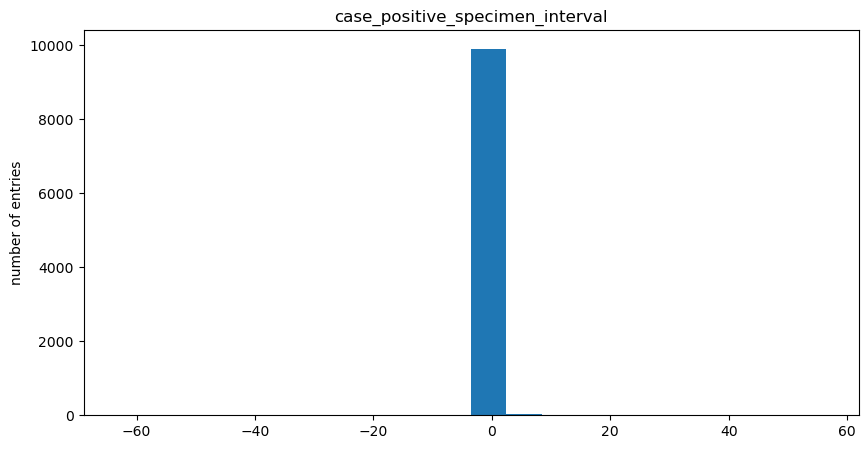

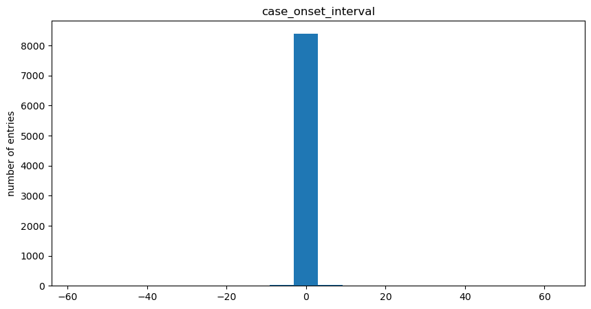

```python
# Plot histograms individual sheet for all the continuous features
for col in continuous_features:
    f = df[col].plot(kind='hist', figsize=(10,5), bins=20)
    plt.title(col)
    plt.ylabel('number of entries')
    plt.show()
#     plt.savefig('continuous_histograms_1-1.pdf')
```

### As we can see in the histograms above, there is a huge gap between each columns (the value_counts analysis can be found below), there is only tiny slight columns showing around value of 0. For further deep dive, add parameter "log = True" and plot histograms again after presenting these values.

```python
# Value_counts analysis
# Check for irregular cardinality & permitted values in categorial features.

print("Weeks between earliest date and date of first positive specimen collection:\n- case_positive_specimen_interval:", df['case_positive_specimen_interval'].value_counts(), '\n\n')

print("Weeks between earliest date and date of symptom onset:\n- case_onset_interval:", df['case_onset_interval'].value_counts(), '\n\n')
```

```
Weeks between earliest date and date of first positive specimen collection:
- case_positive_specimen_interval: 0      8822
1       930
2       108
-1       36
3        25
4        10
-2        8
5         7
9         5
6         3
-3        3
21        3
31        2
18        2
28        2
30        2
8         2
24        2
12        2
-4        2
41        1
-14       1
23        1
40        1
26        1
-60       1
32        1
-63       1
27        1
-26       1
29        1
-49       1
-52       1
11        1
56        1
-33       1
54        1
-54       1
-30       1
```

[output cut: 24 more lines]

```
5         2
9         2
64        1
26        1
39        1
-58       1
-12       1
-55       1
21        1
49        1
27        1
-23       1
-47       1
20        1
Name: case_onset_interval, dtype: Int64
```

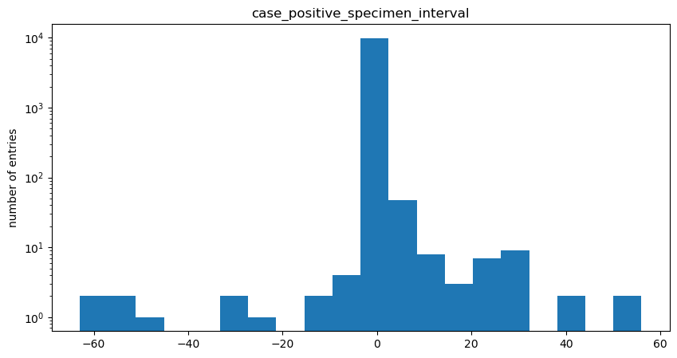

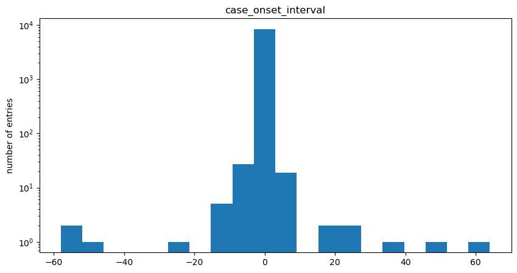

```python
# Plot histograms individual sheet for all the continuous features with log = True
with PdfPages('continuous_histograms_1-1.pdf') as pp:
    for col in continuous_features:
        f = df[col].plot(kind='hist', figsize=(10,5), bins=20, log = True)
        plt.title(col)
        plt.ylabel('number of entries')
        pp.savefig(f.get_figure())
        plt.show()
```

## Plot box plots individual sheet for all the continuous features.

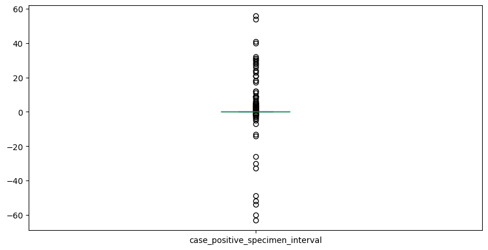

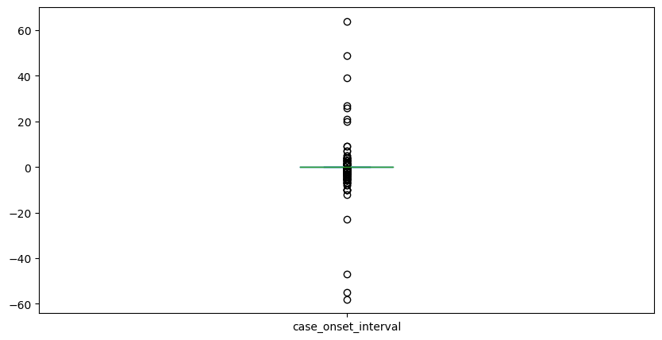

```python
# Plot bar plots for all the continuous features
with PdfPages('continuous_boxplots_1-1.pdf') as pp:
    for col in continuous_features:
        f = df[col].plot(kind='box', figsize=(10,5))
        pp.savefig(f.get_figure())
        plt.show()
```

## Plot bar plots individual sheet for all the categorical features.

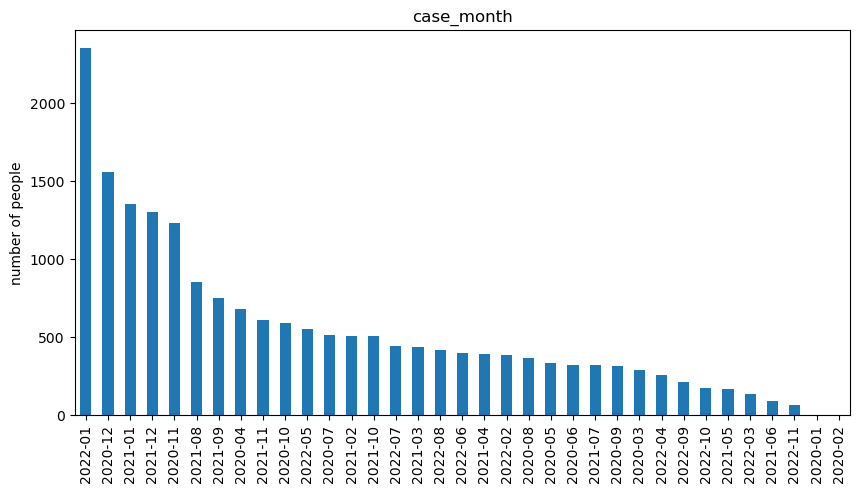

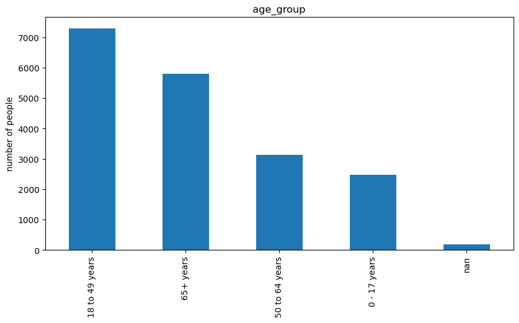

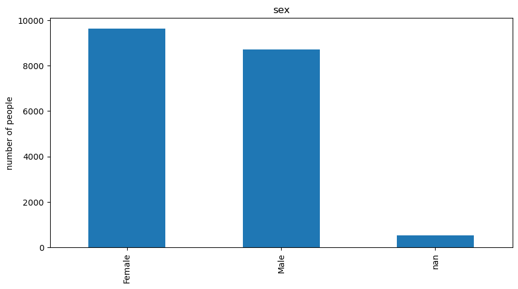

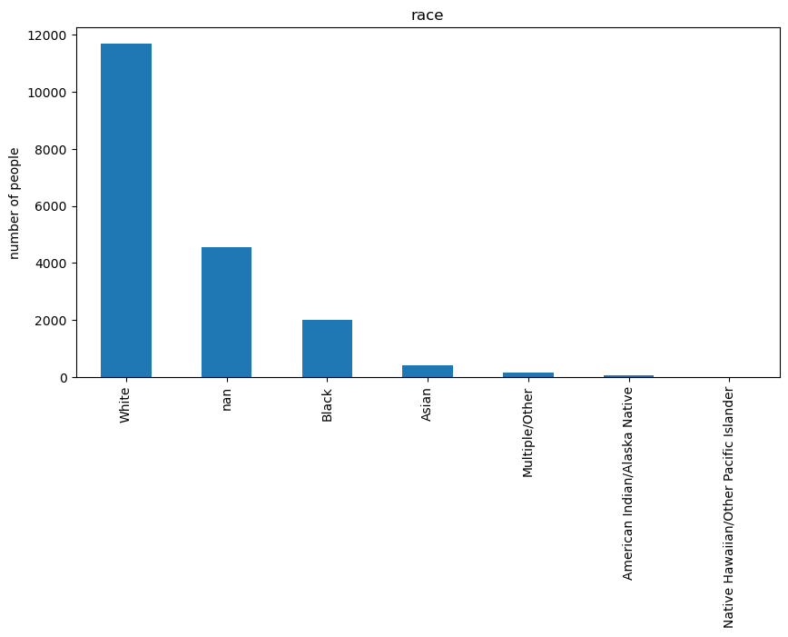

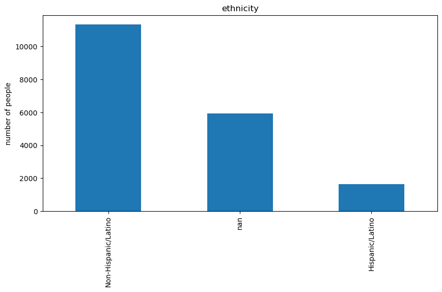

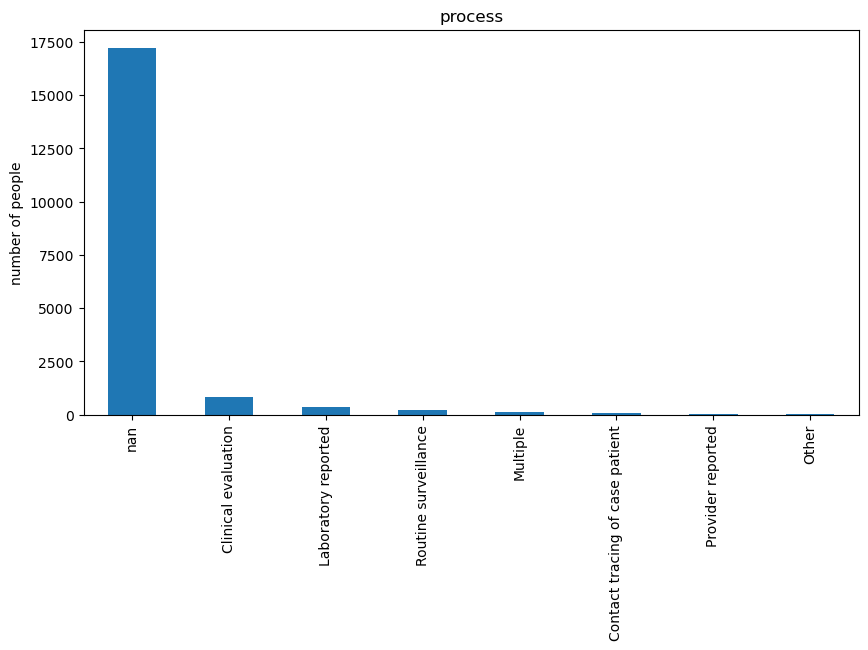

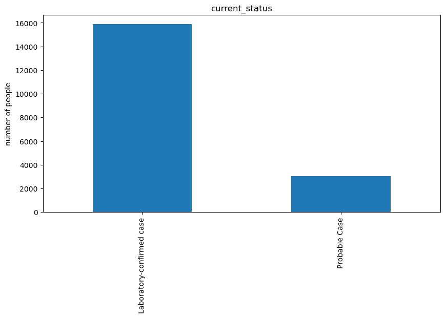

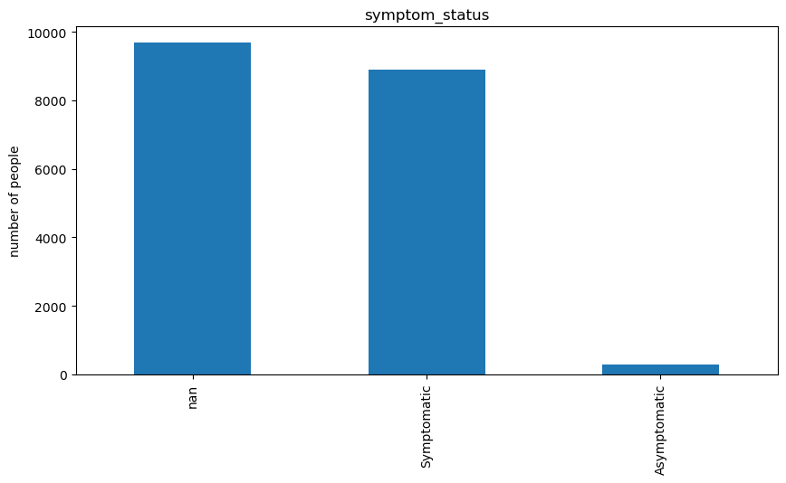

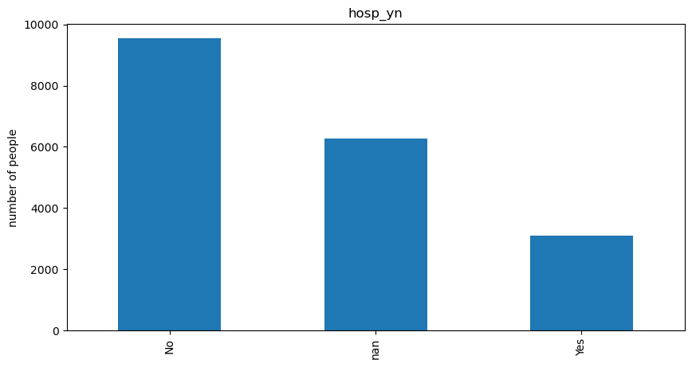

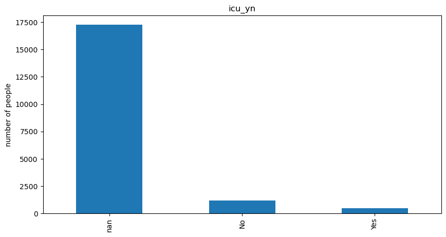

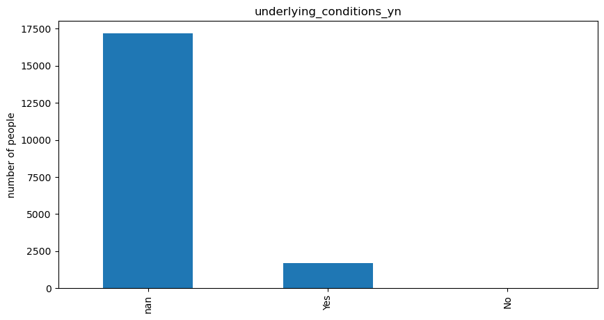

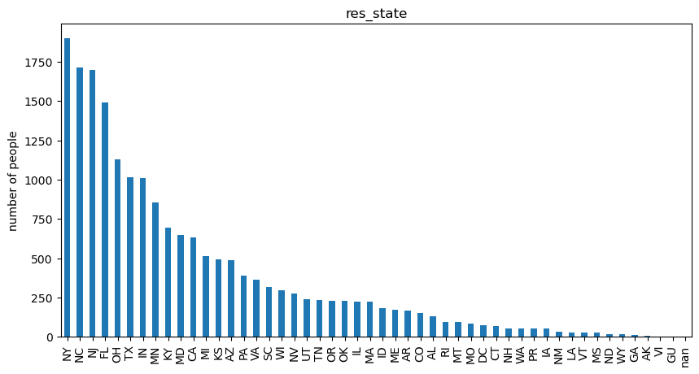

[4 more figures not shown]

```python
# Plot bar plots for all the catagorical features
category_columns_rm = ['case_month', 'age_group', 'sex', 'race', 'ethnicity', 'process', 'current_status', 'symptom_status', 'hosp_yn', 'icu_yn', 'underlying_conditions_yn', 'res_state', 'death_yn']
category_columns_rm1 = ['case_month', 'age_group', 'sex', 'race', 'ethnicity', 'process', 'current_status', 'symptom_status', 'hosp_yn', 'icu_yn', 'underlying_conditions_yn', 'res_state', 'res_county', 'death_yn', 'county_fips_code', 'exposure_yn']
with PdfPages('categorial_barplots_1-1.pdf') as pp:
    for col in category_columns_rm1:
        if col in category_columns_rm:
            f = df[col].value_counts(dropna=False).plot(kind='bar', figsize=(10,5))
            plt.title(col)
            plt.ylabel('number of people')
            plt.show()
        else:
            res_county = df[col].value_counts()
            f = res_county.nlargest(25).plot(kind='bar', figsize=(10,5))
            plt.title(col)
            plt.ylabel('number of people')
            plt.show()
        pp.savefig(f.get_figure())
```

```python
# Check for irregular cardinality & permitted values in categorial features.

print("Number of Unique values for:\n- race:", df['race'].value_counts(), '\n\n')

print("Number of Unique values for:\n- whether the patient has the underlying medical conditions:", df['underlying_conditions_yn'].value_counts(), '\n\n')

print("Number of Unique values for:\n- state of residence:", df['res_state'].value_counts())
```

```
Number of Unique values for:
- race: White                                     11679
Black                                      2018
Asian                                       421
Multiple/Other                              147
American Indian/Alaska Native                75
Native Hawaiian/Other Pacific Islander        1
Name: race, dtype: int64


Number of Unique values for:
- whether the patient has the underlying medical conditions: Yes    1701
No       22
Name: underlying_conditions_yn, dtype: int64


Number of Unique values for:
- state of residence: NY    1897
NC    1713
NJ    1696
FL    1493
OH    1127
TX    1013
IN    1008
MN     857
KY     693
MD     650
CA     634
MI     512
KS     491
AZ     487
PA     388
VA     364
SC     318
WI     296
NV     273
UT     241
TN     232
OR     230
OK     229
```

[output cut: 12 more lines]

```
NH      55
WA      55
PR      54
IA      51
NM      33
LA      28
VT      28
MS      27
ND      18
WY      17
GA      13
AK       4
VI       3
GU       2
Name: res_state, dtype: int64
```

# Initial Findings

### Initial findings and detailed discussion for each feature can be found in the accompanying *Yu-Feng-22200055-Data_Quality_Report_Initial_Findings.pdf* file

# Data Understanding: Data Quality Plan

In this section we list all features and the observations and actions involving those features, as a step towards obtaining a cleaner dataset.

## 1. Data Understanding: check data current status

```python
# List all features that need to be discussed in the data quality plan
df.nunique()
```

```
case_month                           35
res_state                            49
state_fips_code                      49
res_county                          864
county_fips_code                   1208
age_group                             4
sex                                   2
race                                  6
ethnicity                             2
case_positive_specimen_interval      44
case_onset_interval                  29
process                               7
exposure_yn                           1
current_status                        2
symptom_status                        2
hosp_yn                               2
icu_yn                                2
death_yn                              2
underlying_conditions_yn              2
dtype: int64
```

```python
df.dtypes
```

```
case_month                         category
res_state                          category
state_fips_code                    category
res_county                         category
county_fips_code                   category
age_group                          category
sex                                category
race                               category
ethnicity                          category
case_positive_specimen_interval       Int64
case_onset_interval                   Int64
process                            category
exposure_yn                        category
current_status                     category
symptom_status                     category
hosp_yn                            category
icu_yn                             category
death_yn                           category
underlying_conditions_yn           category
dtype: object
```

## 2. Data Understanding: Data Quality Plan for the cleaned CSV file.

In this section we list all features and the observations and actions involving those features, as a step towards obtaining a cleaner dataset.

### The initial list of issues as identified in the **Yu-Feng-22200055-Data_Quality_Report_Initial_Findings.pdf**:

- Logical tests in part 1 had some failures which should be handled.
- Special value ‘missing’ and 'unknown' appeared in many rows covering multiple features. Given that values of Unknown and Missing is also invalid as NAN value, convert these values to NAN value for further analysis.
- Special negative values appears in 2 features. *case_positive_specimen_interval* & *case_onset_interval*. It indicates positive specific date/onset date is earlier than cdc case earliest date, which makes no sense.
- Different scales used for similar features - Categorical features *res_county* & *county_fips_code* are measuring the same event and are using the same numerical mappings. One-to-one mapping needs to be picked for consistency.
- Presence of outliers - There are a significant number of outliers present across a range of different features. They initially look implausible and will need to be investigated further.